# 06-dendritic-characterization

Sam Chen

2026-01-27

## Setup

```r
# Load libraries
library(rprojroot)
library(dplyr)
library(Seurat)
library(patchwork)
library(ggplot2)
library(tidyverse)
library(SeuratObject)
library(scCustomize)
library(AUCell)
library(msigdbr)
library(sccomp)
library(pheatmap)
library(fgsea)

# Define directories
root_dir <- find_root(has_dir(".git"))
data_dir <- file.path(root_dir, "data", "v3")
analysis_dir <- file.path(root_dir, "analyses", "murine-cart-tumor")
results_dir <- file.path(analysis_dir, "results")
plot_dir <- file.path(analysis_dir, "plots")

# Source custom theme
source(file.path(root_dir, "figures", "theme.R"))

# Source function
source(file.path(analysis_dir, "util", "run_doubletfinder.R"))
source(file.path(analysis_dir, "util", "run_soupx.R"))

# set random seed
set.seed(1234)
```

## Load Data

```r
# Load Seurat object
dc_obj <- readRDS(file.path(results_dir, "cart_dc_subclusters.rds"))
```

## Visualize dc subclusters

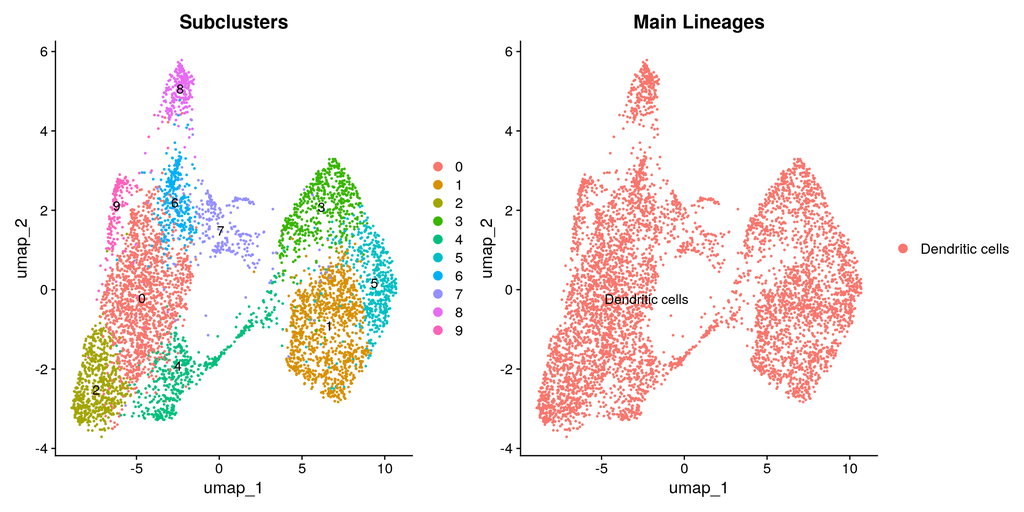

```r
p1 <- DimPlot(dc_obj, reduction = "umap", group.by = "seurat_clusters", label = TRUE, label.size = 4) +
  ggtitle("Subclusters")
p2 <- DimPlot(dc_obj, reduction = "umap", group.by = "cell_type", label = TRUE, label.size = 4) +
  ggtitle("Main Lineages")

p1 + p2
```

## Cluster marker genes

```r
cluster_markers <- FindAllMarkers(dc_obj,
                                  assay = "RNA",
                                  slot = "data",
                                  only.pos = TRUE,
                                  min.pct = 0.5,
                                  logfc.threshold = 0.5)

write.csv(cluster_markers, file.path(results_dir, "dc_subcluster_markers.csv"), row.names = FALSE)
```

## Visualize marker genes

[output not shown]

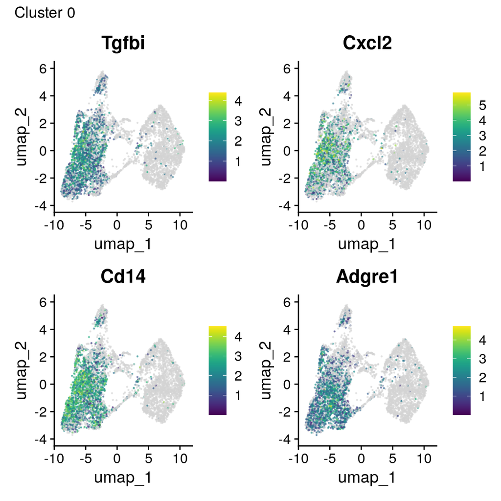

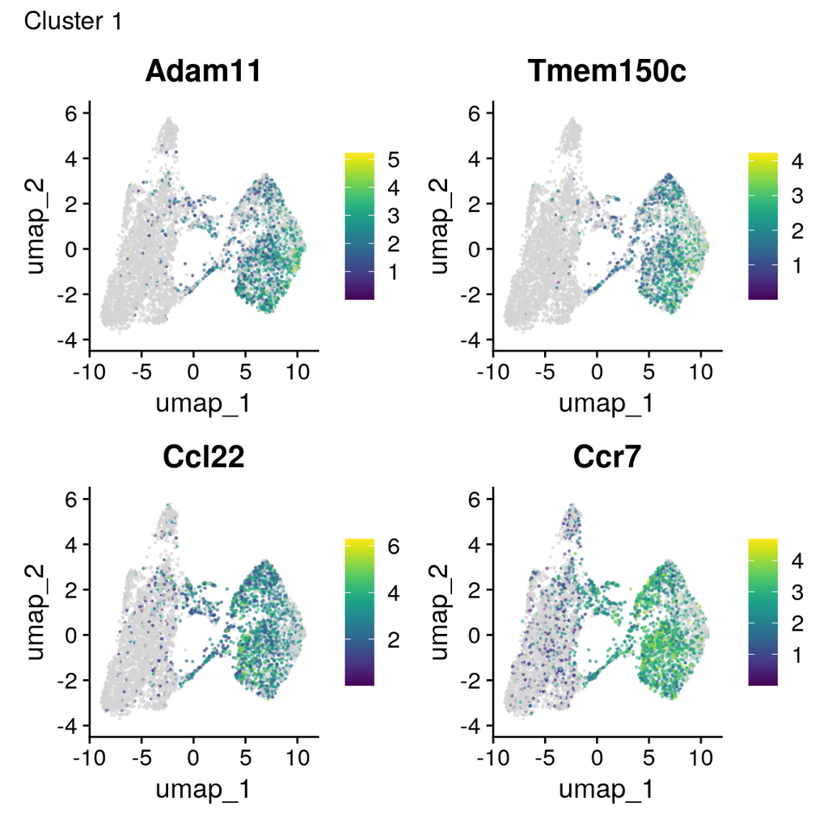

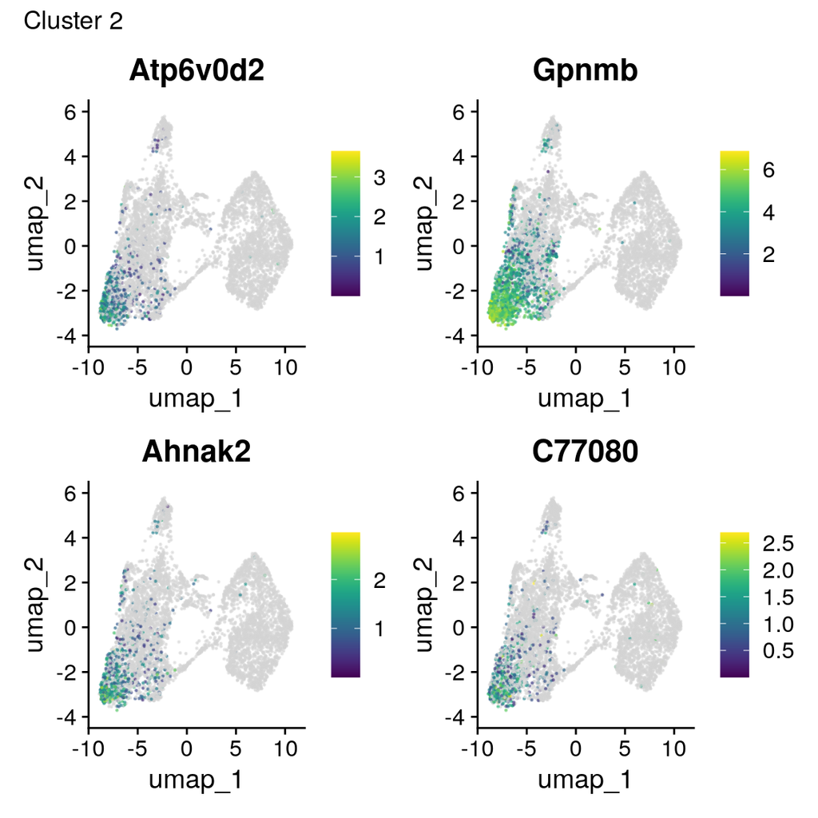

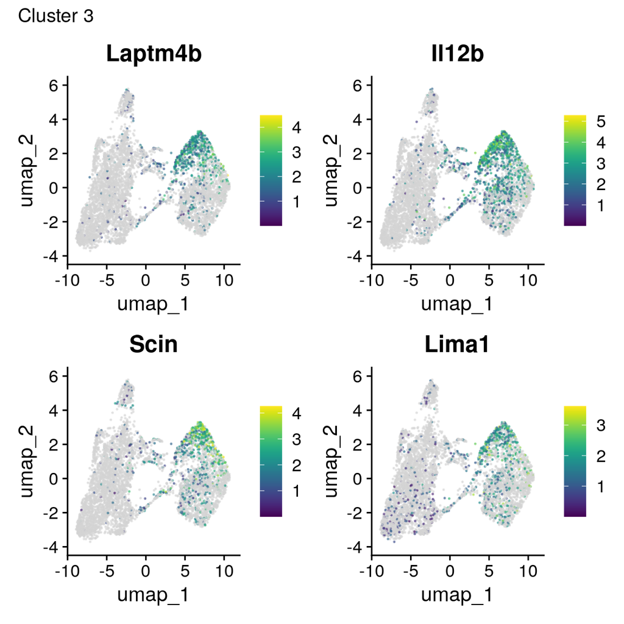

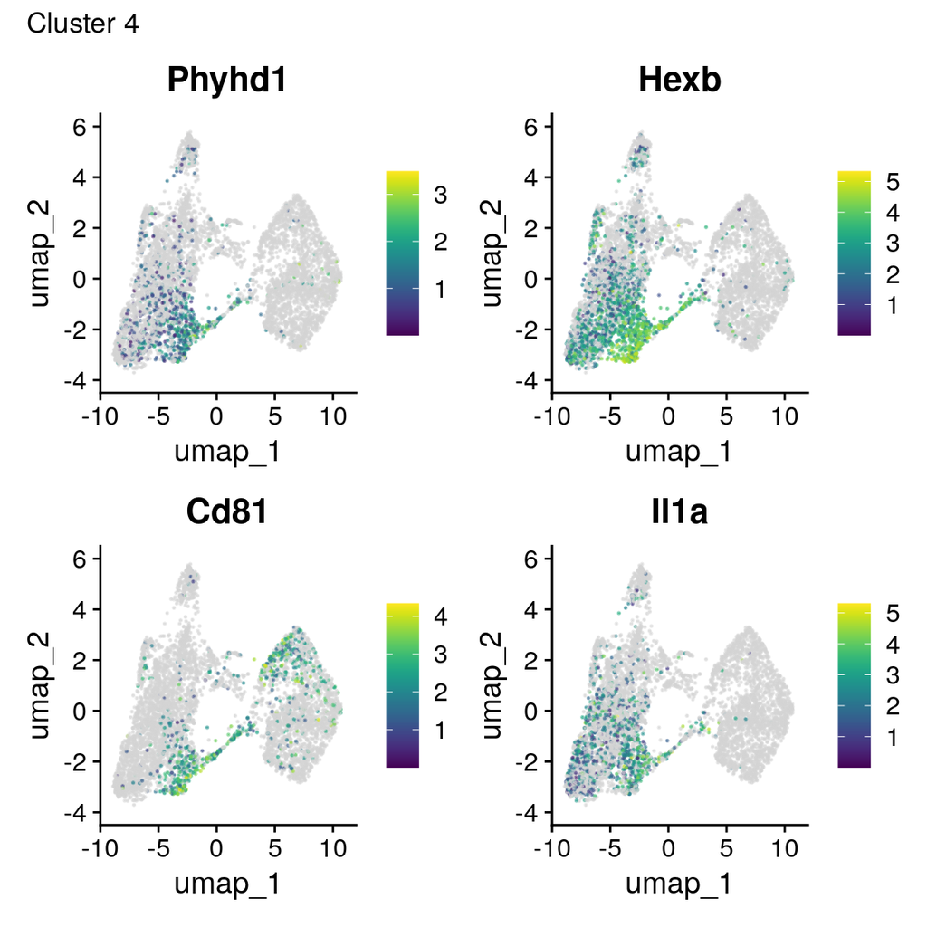

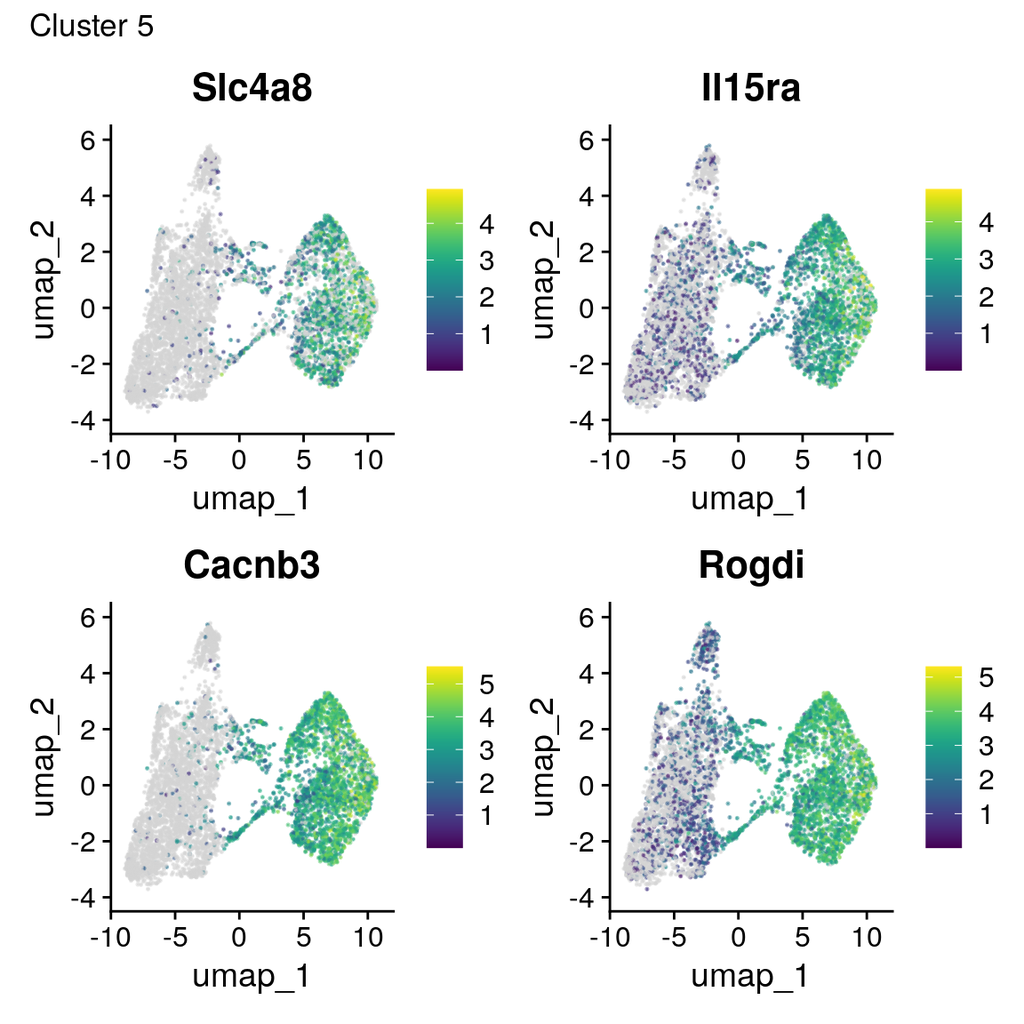

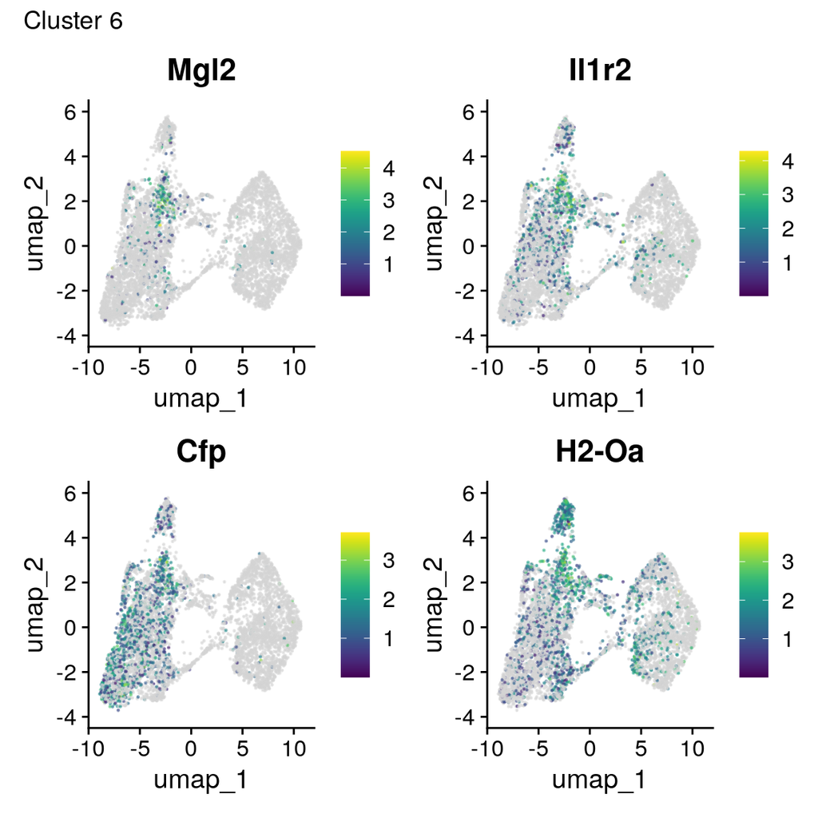

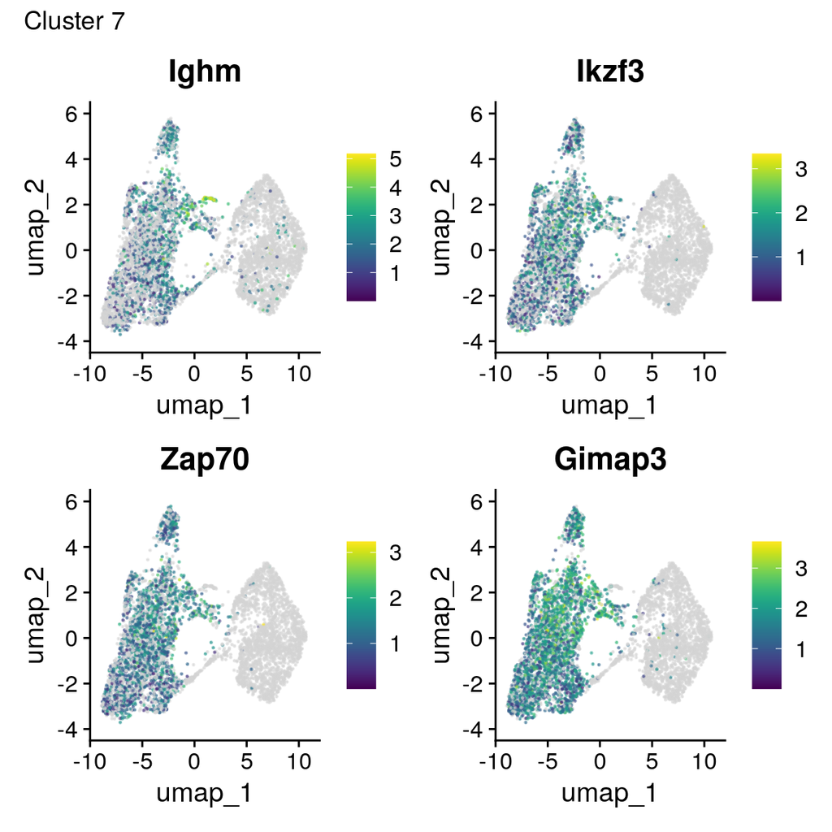

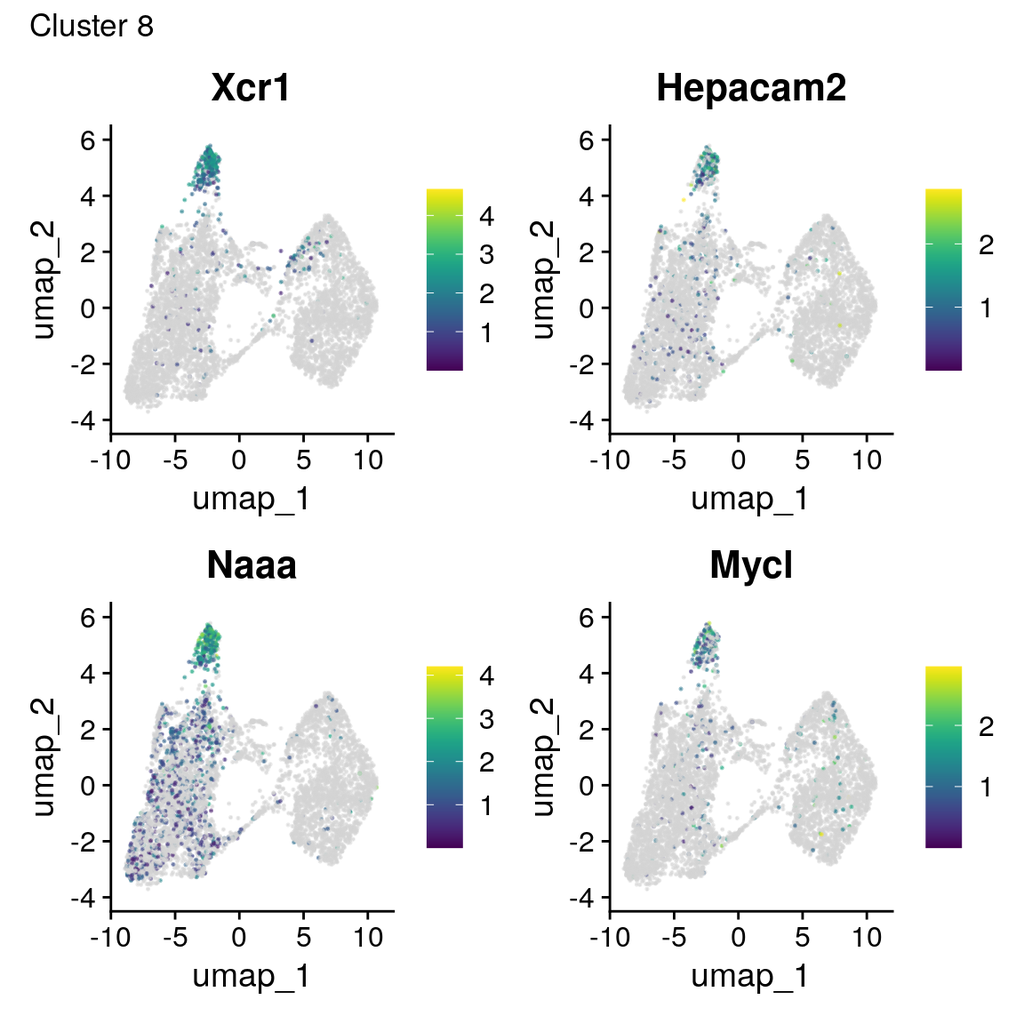

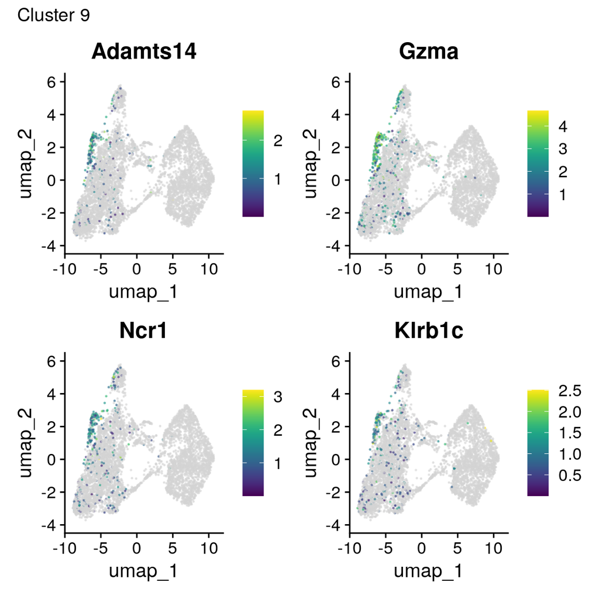

```r
top_markers_table <- cluster_markers %>%
  group_by(cluster) %>%
  slice_max(order_by = avg_log2FC, n = 4) %>%
  ungroup() %>%
  arrange(cluster, desc(avg_log2FC))

for (clust in unique(top_markers_table$cluster)) {
  clust_markers <- top_markers_table %>% filter(cluster == clust) %>% pull(gene)
  p <- FeaturePlot_scCustom(dc_obj, features = clust_markers, reduction = "umap", pt.size = 0.1, alpha_exp = 0.5, order=FALSE, colors_use = viridis_light_high) +
    plot_annotation(title = paste0("Cluster ", clust))
  print(p)
}
```

## Reannotate clusters by their expression profiles

```r
new_cluster_ids <- c(
  "0" = "Myeloid cells",
  "1" = "Migratory DC",
  "2" = "Myeloid cells",
  "3" = "Inflammatory DC (IL12+)",
  "4" = "Myeloid cells",
  "5" = "Migratory DC",
  "6" = "cDC2",
  "7" = "Lymphocytes",
  "8" = "cDC1",
  "9" = "Lymphocytes"
)

dc_obj$dc_subtype <- plyr::mapvalues(
  x = dc_obj$seurat_clusters,
  from = names(new_cluster_ids),
  to = new_cluster_ids
)
```

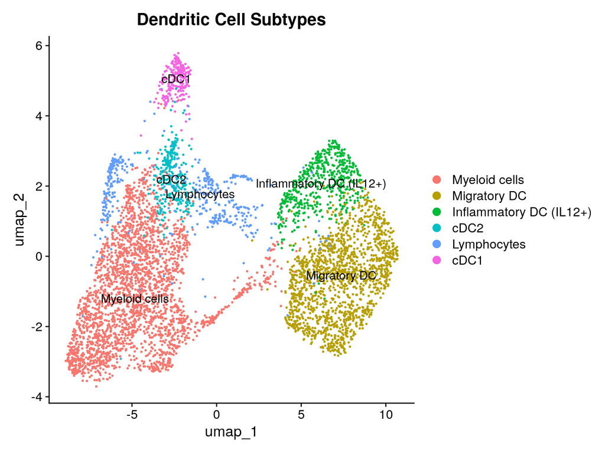

```r
DimPlot(dc_obj, reduction = "umap", group.by = "dc_subtype", label = TRUE) +
  ggtitle("Dendritic Cell Subtypes")
```

```r
ggsave(file.path(plot_dir, "dc_subtypes_umap.png"), width = 8, height = 6)
```

## Marker genes on subsets

```r
subtype_markers <- FindAllMarkers(dc_obj,
                                  assay = "RNA",
                                 group.by = "dc_subtype",
                                  slot = "data",
                                  only.pos = TRUE,
                                  min.pct = 0.5,
                                  logfc.threshold = 0.5)

write.csv(subtype_markers, file.path(results_dir, "dc_subtype_markers.csv"), row.names = FALSE)
```

```r
subtype_markers <- read.csv(file.path(results_dir, "dc_subtype_markers.csv"))

top50_markers <- subtype_markers %>%
  group_by(cluster) %>%
  top_n(n = 50, wt = avg_log2FC)

# scale top markers in RNA assay
dc_obj <- ScaleData(dc_obj, features = unique(top50_markers$gene), assay = "RNA")
```

```r
# separate heatmap for each cluster, save in one pdf file
pdf(file = file.path(plot_dir, "dc_subtype_heatmap_top_markers.pdf"), width = 16, height = 8)
for (lineage in unique(top50_markers$cluster)) {
  markers <- top50_markers %>%
    filter(cluster == lineage) %>%
    pull(gene)

  p <- DoHeatmap(dc_obj, features = markers, group.by = "dc_subtype", assay = "RNA", cells = 1:500) +
    ggtitle(paste("Top Markers for", lineage)) +
    theme(plot.title = element_text(hjust = 0.5, face = "bold"))

  print(p)
}
dev.off()
```

## Composition analysis using sccomp

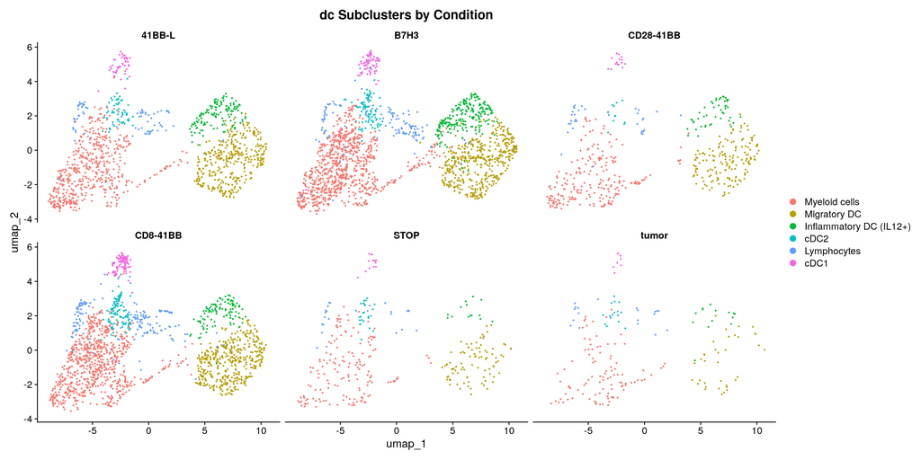

```r
DimPlot(dc_obj, reduction = "umap", group.by = "dc_subtype", split.by = "condition", ncol = 3) +
  ggtitle("dc Subclusters by Condition")
```

```r
ggsave(file.path(plot_dir, "dc_subtypes_by_condition_umap.png"), width = 16, height = 8)
```

```r
sccomp_input <- dc_obj@meta.data |>
  tibble::rownames_to_column("cell") |>
  dplyr::select(
    cell,
    sample = sample,
    cell_group = dc_subtype,
    condition
  ) %>% mutate(condition = factor(condition,
               levels = c('tumor', 'STOP', '41BB-L', 'B7H3', 'CD28-41BB', 'CD8-41BB'))) %>%
  as_tibble()

sccomp_result =
  sccomp_input |>
  sccomp_estimate(
    formula_composition = ~ condition,
    .sample = sample,
    .cell_group = cell_group,
    bimodal_mean_variability_association  = TRUE,
    cores = 4,
    verbose = FALSE
  ) |>
  sccomp_test()
```

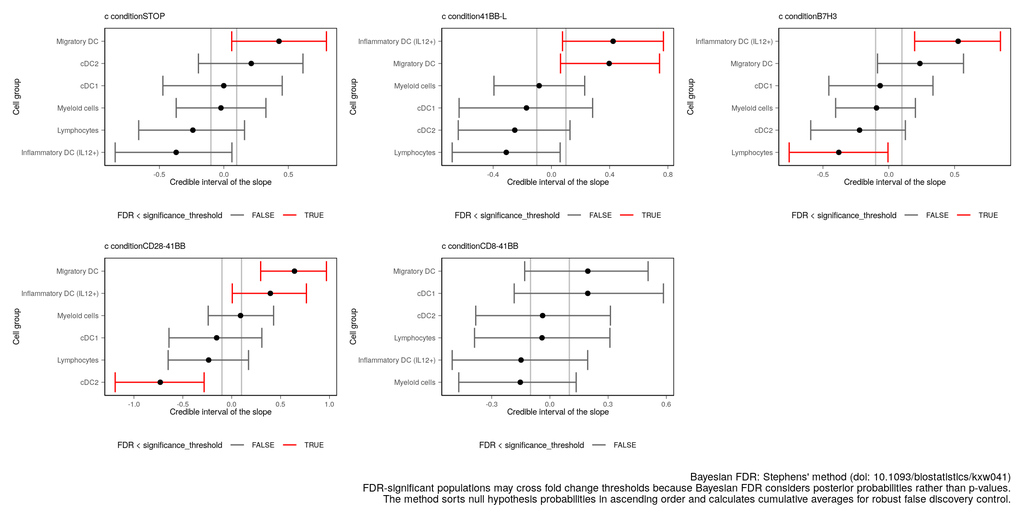

```r
sccomp_result |>
  plot_1D_intervals()
```

```r
ggsave(file.path(plot_dir, "dc_subtype_composition_sccomp.png"), width = 12, height = 6)
```

```r
sccomp_result  |>
   sccomp_proportional_fold_change(
     formula_composition = ~  condition,
     from =  "tumor",
     to = "B7H3"
    ) |>
  select(cell_group, statement)
```

```
## Loading model from cache...
```

```
## Running standalone generated quantities after 1 MCMC chain, with 1 thread(s) per chain...
##
## Chain 1 finished in 0.0 seconds.
```

```
## # A tibble: 6 × 2
##   cell_group              statement
##   <chr>                   <glue>
## 1 Myeloid cells           1.1-fold decrease (from 0.5037 to 0.4493)
## 2 Migratory DC            1.2-fold increase (from 0.2108 to 0.2619)
## 3 Inflammatory DC (IL12+) 1.7-fold increase (from 0.0759 to 0.1272)
## 4 cDC2                    1.3-fold decrease (from 0.0653 to 0.0522)
## 5 Lymphocytes             1.5-fold decrease (from 0.1006 to 0.0686)
## 6 cDC1                    1.1-fold decrease (from 0.0437 to 0.0407)
```

## Relative proportions of clusters between conditions

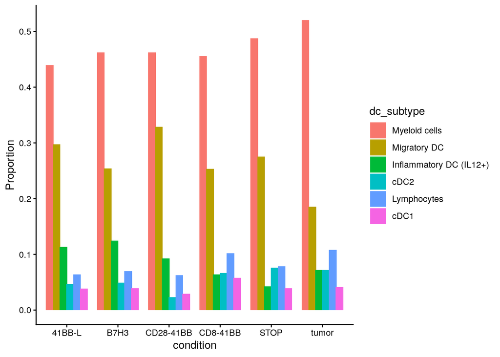

```r
## stacked barplot
prop_df <- dc_obj@meta.data %>%
  dplyr::count(condition, dc_subtype) %>%
  group_by(condition) %>%
  mutate(prop = n / sum(n))

ggplot(prop_df, aes(x = condition, y = prop, fill = dc_subtype)) +
  geom_col(position = position_dodge(width = 0.8)) +
  ylab("Proportion") +
  theme_classic()
```

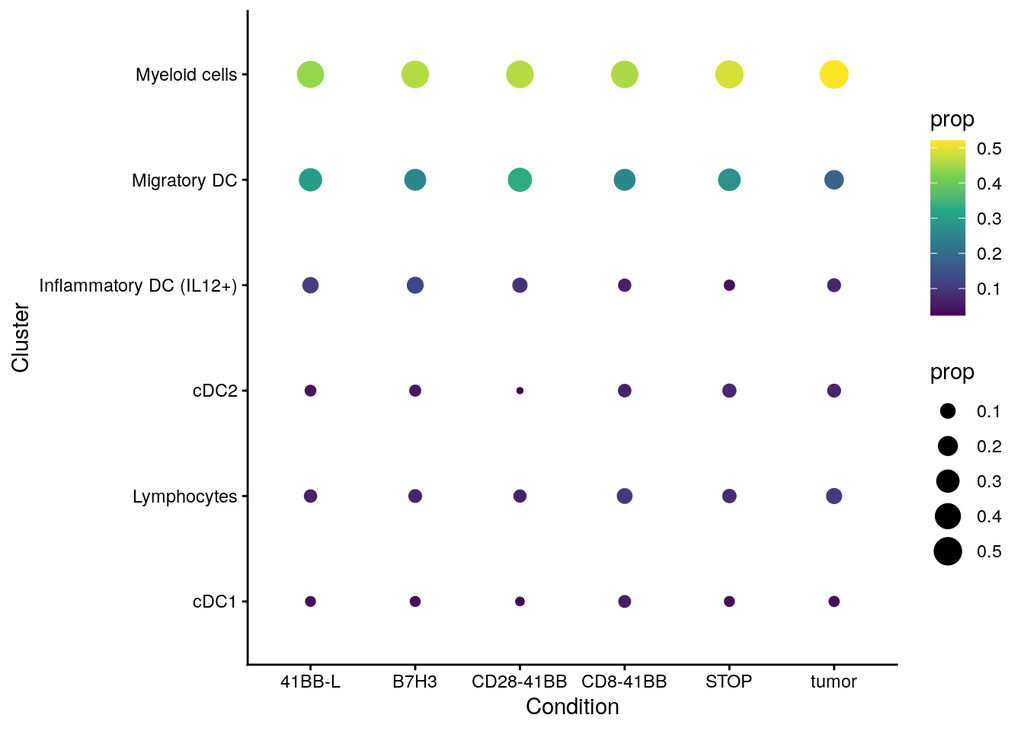

```r
ggsave(file.path(plot_dir, "dc_subtype_proportions_barplot.png"), width = 9, height = 6)

## dotplot of proportions
ggplot(prop_df, aes(x = condition, y = dc_subtype, size = prop, color = prop)) +
  geom_point() +
  scale_color_viridis_c() +
  scale_y_discrete(limits = rev) +
  theme_classic() +
  ylab("Cluster") +
  xlab("Condition")
```

```r
ggsave(file.path(plot_dir, "dc_subtype_proportions_dotplot.png"), width = 9, height = 6)
```

# Gene set enrichment analysis

## AUCell scoring on MSigDB Hallmark Gene sets

```r
# msigdb hallmark
msigdb_hallmark <- msigdbr::msigdbr(species = "Mus musculus", category = "H") %>%
  dplyr::select(gs_name, gene_symbol) %>%
  dplyr::group_by(gs_name) %>%
  dplyr::summarise(genes = list(gene_symbol)) %>%
  deframe()

# c5 onology
msigdb_c5 <- msigdbr::msigdbr(species = "Mus musculus", category = "C5", subcategory = "BP") %>%
  dplyr::select(gs_name, gene_symbol) %>%
  dplyr::group_by(gs_name) %>%
  dplyr::summarise(genes = list(gene_symbol)) %>%
  deframe()

# c7 immune
msigdb_c7 <- msigdbr::msigdbr(species = "Mus musculus", category = "C7") %>%
  dplyr::select(gs_name, gene_symbol) %>%
  dplyr::group_by(gs_name) %>%
  dplyr::summarise(genes = list(gene_symbol)) %>%
  deframe()
```

## Hallmark gene set activity by dc subcluster

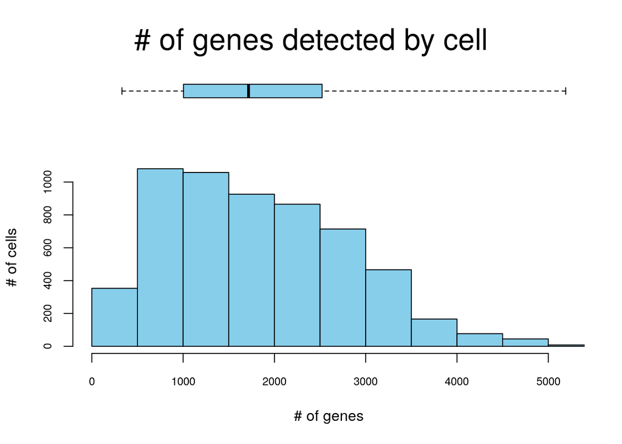

```
##    min     1%     5%    10%    50%   100%
##  330.0  383.0  477.9  600.8 1717.0 5191.0
```

```r
# AUCell on hallmark genesets
cells_rankings <- AUCell_buildRankings(GetAssayData(dc_obj, assay = "RNA", slot = "data"), nCores = 4, plotStats = TRUE)
```

```r
hallmark_AUC <- AUCell_calcAUC(msigdb_hallmark, cells_rankings)
```

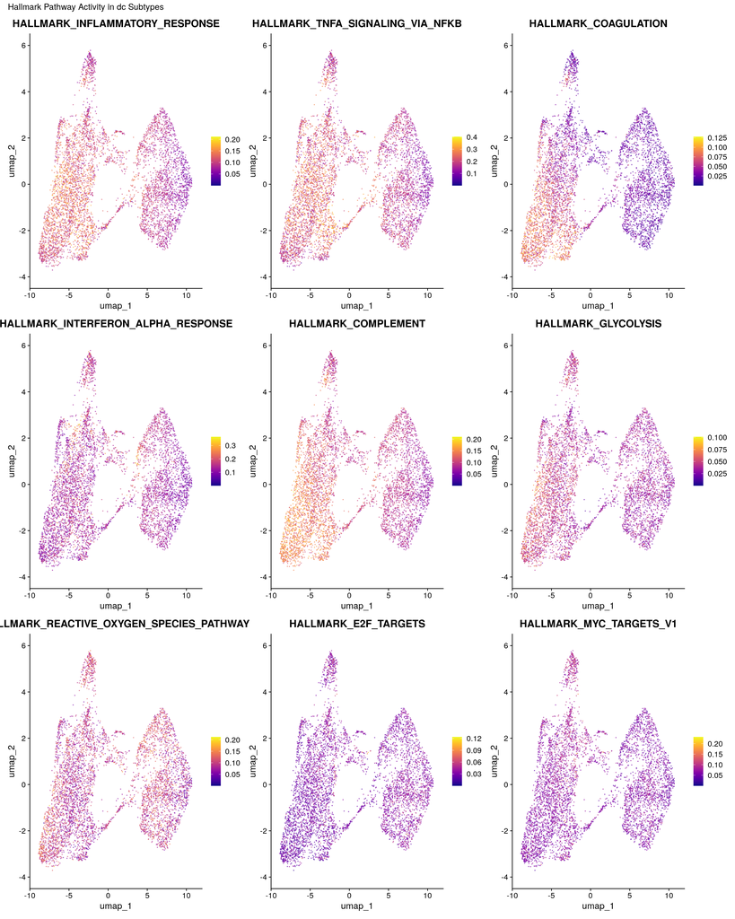

```r
# add hallmark scores to seurat object
hallmark_scores_df <- as.data.frame(t(getAUC(hallmark_AUC)))
dc_obj <- AddMetaData(dc_obj, metadata = hallmark_scores_df)
# visualize selected hallmark pathways
hallmark_pathways_to_plot <- c("HALLMARK_INFLAMMATORY_RESPONSE",
                                "HALLMARK_TNFA_SIGNALING_VIA_NFKB",
                                "HALLMARK_COAGULATION",
                                "HALLMARK_INTERFERON_ALPHA_RESPONSE",
                                "HALLMARK_COMPLEMENT",
                               "HALLMARK_GLYCOLYSIS",
                               "HALLMARK_REACTIVE_OXYGEN_SPECIES_PATHWAY",
                               "HALLMARK_E2F_TARGETS",
                               "HALLMARK_MYC_TARGETS_V1")
FeaturePlot_scCustom(dc_obj, features = hallmark_pathways_to_plot, reduction = "umap",
                     pt.size = 0.1, alpha_exp = 0.5, colors_use = viridis_plasma_light_high) +
  plot_annotation(title = "Hallmark Pathway Activity in dc Subtypes")
```

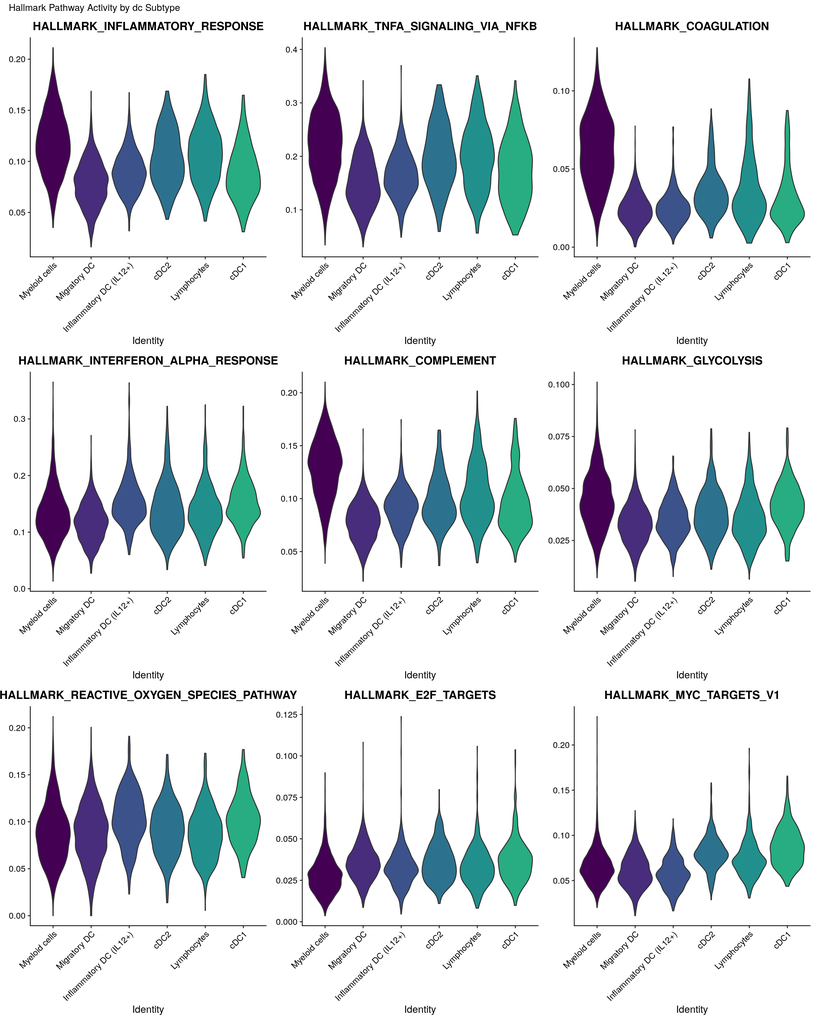

```r
VlnPlot_scCustom(dc_obj, features = hallmark_pathways_to_plot, group.by = "dc_subtype",
                 pt.size = 0, log = FALSE, colors_use = viridis::viridis(9)) +
  plot_annotation(title = "Hallmark Pathway Activity by dc Subtype")
```

# Subtype vs pathway heatmap of AUCell scores

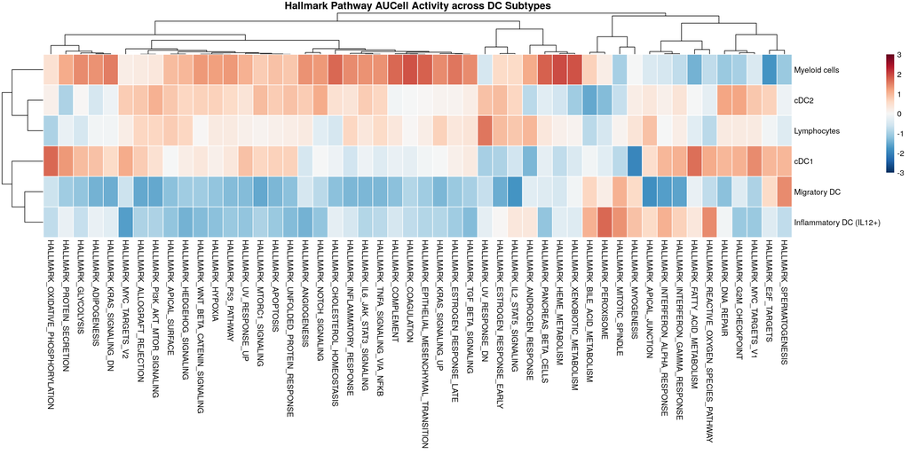

```r
# z scores of AUCell scores across clusters per gene set
hallmark_scores_df$cluster = dc_obj$dc_subtype

avg_hallmark_scores <- hallmark_scores_df %>%
  group_by(cluster) %>%
  summarise(across(starts_with("HALLMARK"), mean)) %>%
  column_to_rownames("cluster")

hallmark_z_scores <- scale(avg_hallmark_scores)


# Color scale
colors <- rev(RColorBrewer::brewer.pal(n = 11, name = "RdBu"))
colors.use <- grDevices::colorRampPalette(colors = colors)(100)
breaks <- seq(-3, 3, length.out = 101)

# save heatmap as pdf
pdf(file = file.path(plot_dir, "dc_subtype_hallmark_auc_heatmap.pdf"), width = 16, height = 8)

hm <- pheatmap::pheatmap(mat = hallmark_z_scores,
                   color = colors.use,
                   border_color = "white",
                   breaks = breaks,
                   clustering_distance_rows = "correlation",
                  clustering_distance_cols = "correlation",
                  main = "Hallmark Pathway AUCell Activity across DC Subtypes")
```

```r
dev.off()
```

## GSEA analysis of Hallmark gene sets

```r
# get foldchanges for each gene per cluster
clusters <- levels(dc_obj$dc_subtype)
fc_list <- lapply(clusters, function(cl){
  df <- FoldChange(
    object = dc_obj,
    group.by = "dc_subtype",
    ident.1 = cl,
    ident.2 = NULL,
    assay = "RNA",
    slot = "data"
  )
  df <- as.data.frame(df)
  df$gene <- rownames(df)

  # Filter by pct.1
  df <- df %>% filter(pct.1 >= 0.05)

  df$cluster <- cl
  df
})
names(fc_list) <- clusters

# rank genes by product of log FCs and -log10 p values
make_rank_vector <- function(df) {
  stat <- df$avg_log2FC
  names(stat) <- df$gene
  stat[is.finite(stat)]
}

fgsea_list_hallmark <- map(fc_list, function(df_cluster) {
  stats_vec <- make_rank_vector(df_cluster)
  print(length(stats_vec))

  fgsea(
    pathways = msigdb_hallmark,
    stats    = stats_vec,
    minSize  = 15,
    maxSize  = 500,
  )
})
```

```
## [1] 8012
## [1] 4947
## [1] 5283
## [1] 7772
## [1] 7901
## [1] 8101
```

```r
fgsea_res_hallmark <- imap_dfr(fgsea_list_hallmark, ~ mutate(.x, cluster = .y))
fgsea_res_hallmark_sig <- fgsea_res_hallmark %>%
  filter(padj < 0.1 & NES > 0) %>%
  arrange(cluster, desc(NES)) %>%
  select(cluster, pathway, NES, pval, padj)
write.csv(fgsea_res_hallmark_sig, file.path(results_dir, "dc_subtype_hallmark_gsea_results.csv"), row.names = FALSE)
```

## GSEA on C5 GO gene sets

```r
fgsea_list_c5 <- map(fc_list, function(df_cluster) {
  stats_vec <- make_rank_vector(df_cluster)
  print(length(stats_vec))

  fgsea(
    pathways = msigdb_c5,
    stats    = stats_vec,
    minSize  = 15,
    maxSize  = 500,
  )
})
```

```
## [1] 8012
## [1] 4947
```

```
## [1] 5283
## [1] 7772
## [1] 7901
```

```
## [1] 8101
```

```r
fgsea_res_c5 <- imap_dfr(fgsea_list_c5, ~ mutate(.x, cluster = .y))
fgsea_res_c5_sig <- fgsea_res_c5 %>%
  filter(padj < 0.1) %>%
  arrange(cluster, desc(NES)) %>%
  select(cluster, pathway, NES, pval, padj)
write.csv(fgsea_res_c5_sig, file.path(results_dir, "dc_subtype_c5_gsea_results.csv"), row.names = FALSE)
```

## GSEA on C7 immune gene sets

```r
fgsea_list_c7 <- map(fc_list, function(df_cluster) {
  stats_vec <- make_rank_vector(df_cluster)
  print(length(stats_vec))

  fgsea(
    pathways = msigdb_c7,
    stats    = stats_vec,
    minSize  = 15,
    maxSize  = 500,
  )
})
```

```
## [1] 8012
## [1] 4947
```

```
## [1] 5283
## [1] 7772
## [1] 7901
```

```
## [1] 8101
```

```r
fgsea_res_c7 <- imap_dfr(fgsea_list_c7, ~ mutate(.x, cluster = .y))
fgsea_res_c7_sig <- fgsea_res_c7 %>%
       filter(padj < 0.1) %>%
       arrange(cluster, desc(NES)) %>%
       select(cluster, pathway, NES, pval, padj)
write.csv(fgsea_res_c7_sig, file.path(results_dir, "dc_subtype_c7_gsea_results.csv"), row.names = FALSE)
```

## Save final dc object

```r
saveRDS(dc_obj, file.path(results_dir, "cart_dc_subtypes.rds"))
```

# Summary of the DC subtypes

AI-assisted summerization of the full marker lists for each DC subtype.

### cDC1

- Key markers: Xcr1, Clec9a, Wdfy4, Mycl, Itgae (CD103)
- Specialized cross-presenting DCs optimized for antigen presentation to CD8⁺ T cells. Support cytotoxic T-cell priming and anti-tumor immunity.
- Literature support:
  - Böttcher et al., Nat. Rev. Immunol. 2018: The role of conventional type 1 dendritic cells (cDC1) in cancer immune control
  - Heger et al., Proc. Natl. Acad. Sci. U.S.A. 2023: XCR1 expression distinguishes human conventional dendritic cell type 1 with full effector functions from their immediate precursors

### cDC2

- Key markers: Ciita, H2-Ab1, H2-Oa, Mgl2, Il1b
- APCs with strong antigen presentation machinery and inflammatory bias. May represent cDC2-leaning cells responding to local inflammatory cues.
- Literature support:
  - Saito et al., Cancers (Basel) 2022: The role of type-2 conventional dendritic cells in the regulation of tumor immunity
  - Cook et al., Nat. Commun. 2025: Mgl2⁺ cDC2s coordinate fungal allergic airway type 2, but not type 17, inflammation in mice

### Migratory DC

- Key markers: Ccr7, Cd80, Fscn1, Ccl22, Il15ra
- Mature DCs undergoing activation and migration toward lymphoid niches. Exhibit enhanced co-stimulatory capacity and are poised to initiate adaptive immune responses.
- Literature support:
  - Liu et al., Cellular & Molecular Immunology. 2021: Dendritic cell migration in inflammation and immunity
  - Hong et al., Front. Pharmacol. 2022: New insights of CCR7 signaling in dendritic cell migration

### Inflammatory DC (IL12+)

- Key markers: Il12b, Ly75 (DEC205), Fscn1, Scin
- Highly activated DCs with pro-inflammatory cytokine output, particularly IL-12. Likely promote Th1 polarization and cytotoxic immune responses.
- Literature support:
  - Heufler et al., Eur. J. Immunol. 1996: Interleukin-12 is produced by dendritic cells and mediates T helper 1 development as well as interferon-gamma production by T helper 1 cells